# Taller del corte #3

David Marquez, Luis Peñaranda, Johan Diaz, Cristian linero y Juan Conrado

Marzo 2025

# Punto 2

Se desea verificar empíricamente los resultados del ejercicio anterior.

## Librerías

Importamos las librerias.

```r
library(tidyverse)
```

```r
library(ggplot2)
```

## Estimadores

Generamos 10000 muestras aleatorias de tamaño n = 100 de una variable uniforme con parámetro 8, calculamos los estimadores para cada muestra y lo guardamos en 3 vectores llamados theta1, theta2 y theta3 según el estimador correspondiente.

```r
set.seed(1)
M = 10000
n = 100
lim_inf = 0
lim_sup = 8
theta1 = rep(NA,M)
theta2 = rep(NA,M)
theta3 = rep(NA,M)


for(i in 1:M){
  x = runif(n, lim_inf, lim_sup)
  theta1[i] = 2 * mean(x)
  theta2[i] = max(x)
  theta3[i] = (n+1) * min(x)
}
```

## Histogramas

Dibujamos los histogramas de los 3 estimadores.

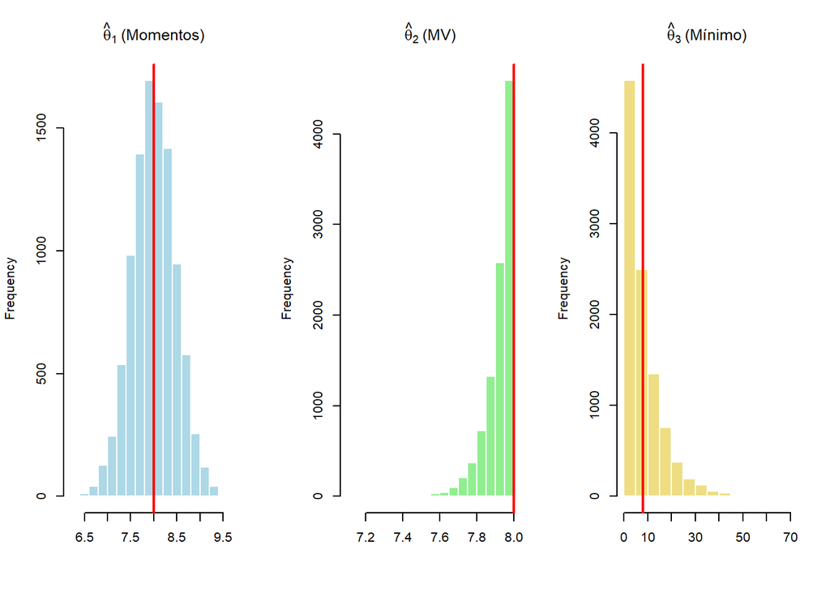

```r
par(mfrow =c(1,3))
hist(theta1, main = expression(hat(theta)[1] ~ "(Momentos)"),
     xlab = "", col = "lightblue", border = "white")
abline(v = lim_sup, col = "red", lwd = 2)

hist(theta2, main = expression(hat(theta)[2] ~ "(MV)"),
     xlab = "", col = "lightgreen", border = "white")
abline(v = lim_sup, col = "red", lwd = 2)

hist(theta3, main = expression(hat(theta)[3] ~ "(Mínimo)"),
     xlab = "", col = "lightgoldenrod", border = "white")
abline(v = lim_sup, col = "red", lwd = 2)
```

```r
par(mfrow = c(1, 1))
```

## Matriz de estimadores

Unimos los 3 vectores con los estimadores en una matriz.

```r
matriz_estimadores <- tibble(theta1, theta2, theta3) %>%
  as.data.frame()
```

## Sesgo y varianzas

Estimamos el sesgo y la varianza para los 3 estimadores. Luego comparamos los valores teóricos con los empíricos.

```r
resultados <- tibble(
  Estimador = c("theta1", "theta2", "theta3"),
  Media = c(mean(theta1), mean(theta2), mean(theta3)),
  Sesgo_estimado = c(mean(theta1) - lim_sup,
                     mean(theta2) - lim_sup,
                     mean(theta3) - lim_sup),
  Varianza_empirica = c(var(theta1), var(theta2), var(theta3)),
  Varianza_teorica = c((lim_sup^2)/(3*n), ((lim_sup^2) * n)/((n+2)*((n+1)^2)), ((lim_sup^2)*n)/(n+2))
)

print(resultados)
```

```
## # A tibble: 3 × 5
##   Estimador Media Sesgo_estimado Varianza_empirica Varianza_teorica
##   <chr>     <dbl>          <dbl>             <dbl>            <dbl>
## 1 theta1     8.00       -0.00124           0.215            0.213
## 2 theta2     7.92       -0.0794            0.00604          0.00615
## 3 theta3     8.10        0.103            64.6             62.7
```

## Gráfico de cajas y bigotes

Hacemos una gráfica de cajas y bigotes de la matriz, que incluye los 3 estimadores y trazamos una línea horizontal mostrando el valor real del parámetro θ.

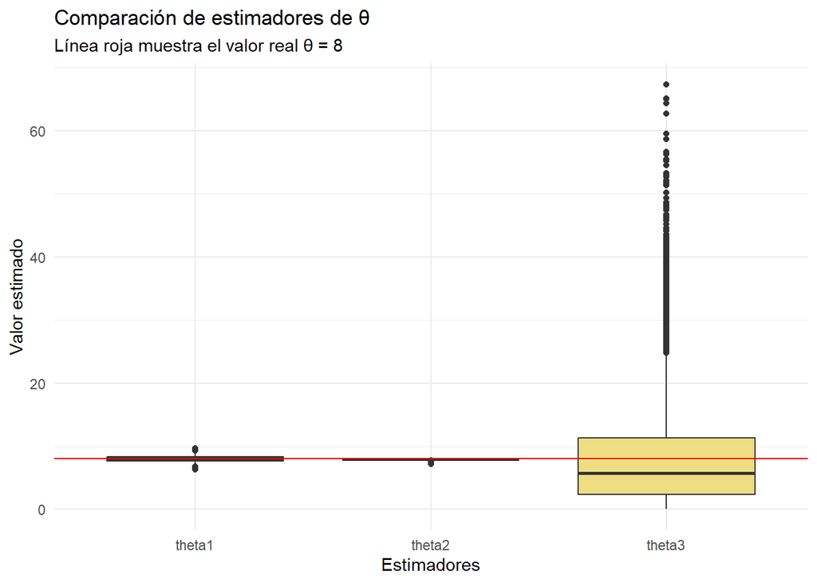

```r
ggplot(mapping = aes(x = rep(c("theta1", "theta2", "theta3"),
                             each = M),
                     y = c(matriz_estimadores$theta1, matriz_estimadores$theta2, matriz_estimadores$theta3),
                     fill = rep(c("theta1", "theta2", "theta3"), each = M))) +
  geom_boxplot() +
  geom_hline(yintercept = lim_sup, linetype = "solid", color = "red") +
  labs(title = "Comparación de estimadores de θ",
       subtitle = paste("Línea roja muestra el valor real θ =", lim_sup),
       y = "Valor estimado",
       x = "Estimadores") +
  scale_fill_manual(values = c("lightblue", "lightgreen", "lightgoldenrod")) +
  theme_minimal() +
  theme(legend.position = "none")
```

## Conclusión

El estimador por momentos (θ̂₁) destaca por ser insesgado (centrado en el valor real θ=8), lo que lo hace confiable en términos de exactitud, aunque con una varianza moderada. El estimador de máxima verosimilitud (θ̂₂) es el más eficiente en precisión (varianza más baja). En contraste, el estimador basado en el mínimo (θ̂₃), aunque teóricamente insesgado, resulta prácticamente ineficiente debido a su alta varianza y sensibilidad a valores extremos, lo que lo hace el menos fiable.

- θ̂₁ es ideal cuando se prioriza insesgamiento.
- θ̂₂ (ajustado) sería óptimo para precisión, pese a su sesgo.
- θ̂₃ muestra el peor desempeño, con alta variabilidad y sensibilidad.